# Integrate STARmap and reference scRNA-seq cells by Seurat

Ningshan Li

2024/09/07

# 1 Summary

In this R Notebook, we integrate STARmap and scRNA-seq reference cells by Seurat.

1. **Inputs**:
   - [`STARmap_cell_nUMI.csv`](https://github.com/az7jh2/SDePER_Analysis/blob/main/Simulation/Run_SDePER_on_simulation_data/Scenario_1/ref_spatial/STARmap_cell_nUMI.csv): raw nUMI counts of all 2,002 STARmap single cells (cells × genes).
   - [`STARmap_cell_celltype.csv`](https://github.com/az7jh2/SDePER_Analysis/blob/main/Simulation/Run_SDePER_on_simulation_data/Scenario_1/ref_spatial/STARmap_cell_celltype.csv): cell type annotation of all 2,002 STARmap cells.
   - `scRNA_data_full.csv`: raw nUMI counts of reference scRNA-seq data (cells × genes). Since the file size of csv file of raw nUMI matrix of all 23,178 cells and 45,768 genes is up to 2.3 GB, we do not provide this file in our repository. It’s just a matrix transpose of [GSE115746_cells_exon_counts.csv.gz](https://www.ncbi.nlm.nih.gov/geo/download/?acc=GSE115746&format=file&file=GSE115746%5Fcells%5Fexon%5Fcounts%2Ecsv%2Egz) in GSE115746 to satisty the file format requirement that rows as cells and columns as genes.
   - [`ref_scRNA_cell_celltype.csv`](https://github.com/az7jh2/SDePER_Analysis/blob/main/Simulation/Run_SDePER_on_simulation_data/Scenario_1/ref_scRNA_seq/ref_scRNA_cell_celltype.csv): cell type annotations for cells of the matched 12 cell types in reference scRNA-seq data.
2. **Outputs**:
   - Figure. UMAP of STARmap and scRNA-seq reference cells after Seurat integration

# 2 Version

```r
version[['version.string']]
```

```
[1] "R version 4.2.2 Patched (2022-11-10 r83330)"
```

```r
print(sprintf('Package %s version: %s', 'Seurat', packageVersion('Seurat')))
```

```
[1] "Package Seurat version: 4.3.0.1"
```

# 3 Read data

## 3.1 Spatial data

### 3.1.1 STARmap cells nUMI

```r
file_name = file.path(home.dir, 'STARmap_cell_nUMI.csv')
starmap_exp = read.csv(file_name, row.names = 1, check.names = F, stringsAsFactors = F)

print(sprintf('load data from file %s', file_name))
```

```
[1] "load data from file /home/hill103/Documents/Spatial/PlatEffDemo/STARmap_cell_nUMI.csv"
```

```r
print(sprintf('Total cells: %d; genes: %d', nrow(starmap_exp), ncol(starmap_exp)))
```

```
[1] "Total cells: 2002; genes: 1020"
```

### 3.1.2 STARmap cell type annotation

```r
file_name = file.path(home.dir, 'STARmap_cell_celltype.csv')
starmap_ct = read.csv(file_name, row.names = 1, check.names = F, stringsAsFactors = F)

stopifnot(all(row.names(starmap_ct) == row.names(starmap_exp)))

print(sprintf('load data from file %s', file_name))
```

```
[1] "load data from file /home/hill103/Documents/Spatial/PlatEffDemo/STARmap_cell_celltype.csv"
```

```r
print(sprintf('annotation for %d cells', nrow(starmap_ct)))
```

```
[1] "annotation for 2002 cells"
```

```r
table(starmap_ct$celltype)
```

```
Astro eL2/3   eL4   eL5   eL6  Endo Micro Oligo PVALB   Smc   SST   VIP
  259   292   327   110   368   134    69   278    61    42    33    29
```

### 3.1.3 Build new `Seurat` with only raw counts and cell type annotations

NOTE: disable filtering.

```r
obj_starmap = CreateSeuratObject(counts = t(as.matrix(starmap_exp)), min.cells = 0, min.features = 0, meta.data = starmap_ct)
print(sprintf('Total cells: %d; genes: %d', ncol(obj_starmap), nrow(obj_starmap)))
```

```
[1] "Total cells: 2002; genes: 1020"
```

```r
obj_starmap[['dataset']] = 'Spatial'
```

Perform normalization.

```r
obj_starmap = NormalizeData(obj_starmap, verbose = FALSE)
```

## 3.2 reference scRNA-seq data

### 3.2.1 scRNA-seq nUMI

```r
file_name = file.path(home.dir, 'scRNA_data_full.csv')
ref_exp = read.csv(file_name, row.names = 1, check.names = F, stringsAsFactors = F)

print(sprintf('load data from file %s', file_name))
```

```
[1] "load data from file /home/hill103/Documents/Spatial/PlatEffDemo/scRNA_data_full.csv"
```

```r
print(sprintf('Total cells: %d; genes: %d', nrow(ref_exp), ncol(ref_exp)))
```

```
[1] "Total cells: 23178; genes: 45768"
```

### 3.2.2 scRNA-seq cell type annotation

```r
file_name = file.path(home.dir, 'ref_scRNA_cell_celltype.csv')
ref_ct = read.csv(file_name, row.names = 1, check.names = F, stringsAsFactors = F)

print(sprintf('load data from file %s', file_name))
```

```
[1] "load data from file /home/hill103/Documents/Spatial/PlatEffDemo/ref_scRNA_cell_celltype.csv"
```

```r
print(sprintf('annotation for %d cells', nrow(ref_ct)))
```

```
[1] "annotation for 11835 cells"
```

```r
table(ref_ct$celltype)
```

```
Astro eL2/3   eL4   eL5   eL6  Endo Micro Oligo PVALB   Smc   SST   VIP
  361   968  1350  1679  2773    76    44    61  1211    55  1567  1690
```

Remove cells without cell type annotation.

```r
ref_exp = ref_exp[row.names(ref_ct), ]
print(sprintf('remain %d cells', nrow(ref_exp)))
```

```
[1] "remain 11835 cells"
```

```r
stopifnot(all(row.names(ref_ct) == row.names(ref_exp)))
```

### 3.2.3 Build new `Seurat` with only raw counts and cell type annotations

NOTE: filtering on genes.

```r
obj_ref = CreateSeuratObject(counts = t(as.matrix(ref_exp)), min.cells = 3, min.features = 0, meta.data = ref_ct)
print(sprintf('Total cells: %d; genes: %d', ncol(obj_ref), nrow(obj_ref)))
```

```
[1] "Total cells: 11835; genes: 37949"
```

```r
obj_ref[['dataset']] = 'Reference'
```

Perform normalization.

```r
obj_ref = NormalizeData(obj_ref, verbose = FALSE)
```

# 4 Prepare for integration

Keep overlapped genes in both Spatial and Reference datasets.

```r
overlap_gene = intersect(row.names(obj_starmap), row.names(obj_ref))
print(sprintf('keep %d overlapped genes', length(overlap_gene)))
```

```
[1] "keep 993 overlapped genes"
```

```r
obj_starmap = subset(obj_starmap, features = overlap_gene)
print(sprintf('finall keep Spatial cells: %d; genes: %d', ncol(obj_starmap), nrow(obj_starmap)))
```

```
[1] "finall keep Spatial cells: 2002; genes: 993"
```

```r
obj_ref = subset(obj_ref, features = overlap_gene)
print(sprintf('finall keep Reference scRNA-seq cells: %d; genes: %d', ncol(obj_ref), nrow(obj_ref)))
```

```
[1] "finall keep Reference scRNA-seq cells: 11835; genes: 993"
```

We use default **30** PCs for integration.

```r
pc_num = 30
```

# 5 Standard `Seurat` integration workflow

- Default [`FindIntegrationAnchors`](https://satijalab.org/seurat/reference/findintegrationanchors) settings in Seurat 4.0
  - `dims = 1:30`
  - `k.anchor = 5`
  - `k.filter = 200`
  - `k.score = 30`
- NOTE here we use 2,000 features.

```r
# create a list of Seurat objects
obj_list = list()
obj_list[['Spatial']] = obj_starmap
obj_list[['Reference']] = obj_ref

obj_list = lapply(X=obj_list, FUN=function(x) {
  x = FindVariableFeatures(x, selection.method = "vst", nfeatures = 2000, verbose = FALSE)
})

# select features that are repeatedly variable across datasets for integration (NEW in Seurat 4.0)
features = SelectIntegrationFeatures(object.list = obj_list)

# increase the global maxSize
options(future.globals.maxSize = 4194304000)

# k.filter default 200
obj_anchors = FindIntegrationAnchors(obj_list, k.filter = 200, dims = 1:pc_num, anchor.features = features, verbose = F)
```

```
  |                                                  | 0 % ~calculating
  |++++++++++++++++++++++++++++++++++++++++++++++++++| 100% elapsed=01m 03s
```

```r
# this command creates an "integrated" data assay
obj_combined = IntegrateData(anchorset = obj_anchors, dims = 1:pc_num, verbose = F)
```

# 6 Postprocessing

Extract normalized gene expressions after integration, which is equivalent to `log1p(10000*nUMI/sequencing depth of cell)`.

To be consistent with SDePER which use non-log normalized gene expression values, we applied an `expm1` transformation on Seurat integrated normalized gene expressions, followed by divided by 10,000.

NOTE: **negative** Seurat normalized gene expression values exist! We set them as 0.

```r
DefaultAssay(obj_combined) = "integrated"

norm_exp = expm1(obj_combined@assays$integrated@data) / 10000

print(sprintf('%d (%.2f%%) negative expressions; set them to 0', sum(norm_exp<0), sum(norm_exp<0)/(nrow(norm_exp)*ncol(norm_exp))*100))
```

```
[1] "1120303 (8.15%) negative expressions; set them to 0"
```

```r
norm_exp[norm_exp<0] = 0

print(sprintf('get expression of %d cells and %d genes', ncol(norm_exp), nrow(norm_exp)))
```

```
[1] "get expression of 13837 cells and 993 genes"
```

# 7 Draw UMAP

```r
umap_embed = umap::umap(t(as.matrix(norm_exp)))
print(umap_embed)
```

```
umap embedding of 13837 items in 2 dimensions
object components: layout, data, knn, config
```

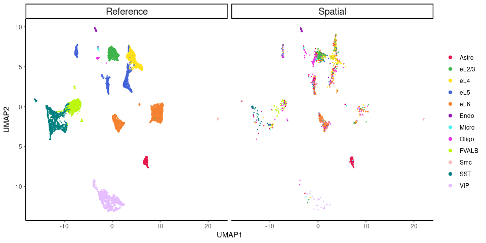

```r
plot_df = umap_embed$layout
plot_df = merge(plot_df, obj_combined@meta.data[, c('celltype', 'dataset')], by = 'row.names')

ggplot(plot_df, aes(x=V1, y=V2, color=celltype)) +
  geom_point(shape=20, size=0.5) +
  theme_classic() +
  scale_color_manual(values = my_color) +
  facet_grid(~dataset) +
  theme(legend.title = element_blank(), strip.text = element_text(size=14)) +
  guides(color = guide_legend(override.aes = list(size = 3))) +
  labs(x = 'UMAP1', y = 'UMAP2')
```